## Elementare Finanzmathematik

### Zinsrechnung

**Zins:** Der Zins kann als Preis für die Übernahme eines Risikos und/oder als Preis für das Leihen von Geld angesehen werden.

Grund für Zins:  
1. **Kreditausfallrisiko**: Risiko, dass der Kunde zahlungsunfähig wird  
2. **Opportunitätskosten**: Kosten aufgrund der entgangenen Möglichkeit, den als Kredit gewährten Betrag anderweitig zu investieren

Notation:

- $K_t$ Kapitalwachstumsfunktion
- $t$ Zeiteinheit (standardmässig in Jahren)
- **p.a.** per annum
- $i$ Zinssatz p.a.

Wie werden bereits angefallene Zinsen behandelt?  
1. **Zinseszinsrechnung**: bereits angefallene (und nicht ausgezahlte) Zinsen in den Folgeperioden wieder mitverzinst  
2. **einfache Verzinsung**: die anfallenden Zinsen schlichtweg angesammelt werden

Wann werden die Zinsen gutgeschrieben?  
1. **nachschüssigen Verzinsung**  
2. **vorschüssige Verzinsung**

Modell:

- Einfache Verzinsung: $K_t = K_0 \cdot (1 + t\cdot i)$
- Zinseszins: $K_t = K_0 \cdot (1 + i)^t$

#### Wichtigste Definitionen

**Diskontfaktor:** $v = \frac{1}{1+i}$ Welcher Betrag muss zum Zeitpunkt t = 0 investiert werden, damit sich nach einem Jahr der normierte Betrag der Höhe 1 ergibt?

**Aufzinsungsfaktor:** $r = 1+i$

**effektiver Zinssatz:** (pro Zeiteinheit) $i$, falls der Einheitsbetrag 1 nach $t$ Zeiteinheiten auf $(1+i)^t$

Beispiel: Bei einem Investment, welches sich über t Jahre erstreckt, werden in den einzelnen Jahren (i.d.R. unterschiedliche) Zinssätze gewährt, i.e. $i_1,\dots,\, i_t$. Interessiert man sich nun für die erzielte durchschnittliche Verzinsung, so sucht man den Effektivzinssatz i für den genannten Zeitraum.

Fall 1: **Zinseszins**
In diesem Fall lautet der Ansatz
$$K_0 \cdot (1+i_1) \cdot \dots \cdot (1+i_t) \overset{!}{=} K_0
\cdot (1+i)^t$$

Den effektiven Zinssatz i erhält man somit als geometrisches Mittel der Aufzinsungsfaktoren, i.e.
$$1+i = \left( \prod_{j=1}^t (1+i_j) \right)^{\frac{1}{t}}$$

Fall 1: **Einfache Verzinsung**
In diesem Fall lautet der Ansatz
$$K_0 \cdot (1 + i_1 \dots + i_t) \overset{!}{=} K_0 \cdot (1 + t
\cdot i)$$

Den effektiven Zinssatz i erhält man somit als arithmetisches Mittel der Aufzinsungsfaktoren, i.e.
$$i = \frac{1}{t} \sum_{j=1}^t i_j$$

**effektiver Diskontsatz:** (pro Zeiteinheit) $d = 1 - v = \frac{i}{1+i} = iv$

Beachte: Die Angabe des Effektivzinssatzes i oder des Effektivdiskontsatzes d zueinander äquivalent:
$$1+i = \left(\frac{1}{1+i}\right)^{-1} =
\left(1-\frac{i}{1+i}\right)^{-1} = (1-d)^{-1}$$

#### Nominelle Verzinsung

Bislang wurde angenommen, dass die Zinsen nur einmal pro Zeiteinheit, d.h. am Ende eines Jahres, fällig werden.

Im Folgenden entfallen auf eine Zeiteinheit (Jahr) k Zinsperioden, welche jeweils eine Länge von $\frac{1}{k}$ des Jahres haben. Folglich werden k-Mal pro Jahr Zinsen (nachschüssig) fällig. Diese Art der Zinsfälligkeit bezeichnet man als **unterjährige Verzinsung**.

Die nachfolgenden Definitionen gewährleisten, dass der Zinsertrag über die gesamte Zeiteinheit mit der Summe der in den zugehörigen Zinsperioden erfolgenden Zinszahlungen übereinstimmt.

Der **nominelle Zinssatz** oder auch **Nominalzinssatz** $i^{(k)}$ pro Zeiteinheit wird durch folgende Gleichung definiert:
$$1 + i = \left(1+\frac{i^{(k)}}{k}\right)^k$$

Anders ausgedrückt:  
Ein nomineller Zinssatz von $i^{(k)}$ p.a. wird in k gleich großen Teilzahlungen (Raten) unterjährig ausgeschüttet. Er stimmt mit einem effektiven Zinssatz von $\frac{i^{(k)}}{k}$ pro $\frac{1}{k}$ eines Jahres überein.

Beachte: Für k = 1 stimmen effektiver und nomineller Zinssatz überein.

Analog existiert auch ein **nomineller Diskontsatz**, welcher mit $d^{(k)}$ bezeichnet und mittels des effektiven Diskontsatzes d definiert wird, nämlich
$$1-d = \left(1-\frac{d^{(k)}}{k}\right)^k.$$
Und wegen $1+i = (1-d)^{-1}$ gilt:
$$\left(1+\frac{i^{(k)}}{k}\right)^{k} =
\left(1-\frac{d^{(k)}}{k}\right)^{-k}$$

### Zahlungsströme (cash flows)

Die Mehrheit der finanziellen Zahlungsvorgänge, insbesondere alle hier betrachteten Zahlungsschemata, lassen sich unter dem gemeinsamen Dach eines Zahlungsstroms darstellen. Die Zeiteinheit beträgt, sofern nichts anderes gesagt wird, wiederum 1 Jahr, und die Verzinsung erfolgt nachschüssig (sowie ggf. unterjährig).

**(diskreter) Zahlungsstrom:** ist eine Serie von Zahlungen $z(t_j)$ , welche zu diskreten Zeitpunkten $t_j$ mit $j \in \{0,\dots, J\}$ gemacht werden. Die Zahlungen $z(t_j)$ können positiv, negativ oder auch Null sein. In vielen Fällen ist $t_j = j$, so dass die Zahlungen äquidistant, d.h. in gleichen Abständen, über die Zeitachse verteilt sind — jedoch ist das nicht notwendigerweise der Fall.

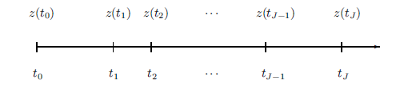

#### Bewertung und Äquivalenz von Zahlungsströmen

Auf Basis eines effektiven Zinssatzes von $i$ p.a. wird der **Wert des Zahlungsstroms** zu einem ausgewählten Zeitpunkt $t^{\ast}\, (t_0 \leq t^{\ast} \leq t_J)$ definiert als (vom Englischen „cash flow“)
$$CF(t^{\ast};i) = \sum_{j=0}^J z(t_j)\,\cdot\, (1+i)^{t^{\ast}-t_j}.$$

Der **Barwert** (**present value**) des Zahlungsstroms zum Zinssatz i, in Zeichen: **PV (i)** (vom Englischen „present value“), ist der Wert des Zahlungsstroms zum Zeitpunkt $t^{\ast} = t_0$, d.h.
$$PV(i) := CF(t_0;i) = \sum_{j=0}^J z(t_j)\,\cdot\, (1+i)^{t_0-t_j}.$$

Der **Endwert** (**terminal value**) des Zahlungsstroms zum Zinssatz i, in Zeichen: **TV (i)** ist der Wert des Zahlungsstroms zum Zeitpunkt $t^{\ast} = t_J$, d.h.
$$TV(i) := CF(t_J;i) = \sum_{j=0}^J z(t_j)\,\cdot\, (1+i)^{t_J-t_j}.$$
Es gilt für drei Zeitpunkte $s$, $t$ und $t^{\ast}$:
$$\begin{align*}
CF(t;i) &= (1+i)^{t-s}\,\cdot\, CF(s;i)\\
CF(t;i) &= (1+i)^{t-s}\,\cdot\, CF(s;i)\\
CF(t^{\ast};i) &= (1+i)^{t^{\ast}}\,\cdot\,PV(i)\\
TV(i) &= (1+i)^{t_J}\,\cdot PV(i)\\
PV(i) &= v^{t_J}\,\cdot TV(i)
\end{align*}$$

#### Spezielle Zahlungsströme

Für diese speziellen Bar- und Endwerte hat sich eine besondere Notation entwickelt, welche sich auch in der Versicherungsmathematik in sehr ähnlicher Form wiederfinden wird.

Die Zeiteinheit betrage weiterhin 1 Jahr, und der jährliche (effektive) Zinssatz sei $i$ p.a.  
Die jährlichen Zahlungen haben jeweils die normierte Höhe 1 (sofern nichts anderes gesagt wird).

##### Einmalzahlung

Eine **Einmalzahlung** ist eine Zahlung, die einmalig zu einem vorab festgelegten Zeitpunkt geleistet wird.

Einmalzahlung nach $n$ Jahren:  
Zugehöriger Zahlungsstrom: $J=n,\, j\in\{0,\dots,n\}$ mit $z(t_j)=0$ für $t_j= 0,\dots,n-1$ und $z(n)=1$.  
Zugehöriger Barwert: $PV(i) = CF(0;i) = v^n$  
Zugehöriger Endwert: $TV(i) = CF(n;i) = 1$

Einmalzahlung sofort:  
Zugehöriger Zahlungsstrom: $J=n,\, j\in\{0,\dots,n\}$ mit $z(0)=1$ und $z(t_j)=0$ für $t_j= 1,\dots,n$.  
Zugehöriger Barwert: $PV(i) = CF(0;i) = 1$  
Zugehöriger Endwert: $TV(i) = CF(n;i) = (1+i)^n$

##### Zeitrenten

Da die Zahlungen deterministisch sind, handelt es sich bei den folgenden Zahlungsschemata um Zeitrenten.  
Die Rentenzahlungen können entweder vorschüssig zu Beginn oder nachschüssig, d.h. am Ende des jeweiligen Jahres, erfolgen.